# Deep Learning in Python

## Load data into data frame

```python
# Load the CSV file into a DataFrame
train_data = pd.read_csv('train_labels.csv')

# Preview the data
train_data.head()
```

|  | id | label |
| --- | --- | --- |
| 0 | f38a6374c348f90b587e046aac6079959adf3835 | 0 |
| 1 | c18f2d887b7ae4f6742ee445113fa1aef383ed77 | 1 |
| 2 | 755db6279dae599ebb4d39a9123cce439965282d | 0 |
| 3 | bc3f0c64fb968ff4a8bd33af6971ecae77c75e08 | 0 |
| 4 | 068aba587a4950175d04c680d38943fd488d6a9d | 0 |

### Basic Data Overview

In this section, we are going to get a basic overview of the dataset by responding to the following questions:

Number of Samples: How many image patches are available in total.

Class Distribution: Count how many images belong to each class (cancer or no cancer).

Missing Values: Check for any missing data in the Image ID or Label columns.

```python
# Check the size of the dataset
print(f"Number of samples: {train_data.shape[0]}")
```

```
Number of samples: 220025
```

```python
# Check for missing values
print(train_data.isnull().sum())
```

```
id       0
label    0
dtype: int64
```

```python
# Check class distribution
print(train_data['label'].value_counts())
```

```
0    130908
1     89117
Name: label, dtype: int64
```

```python
train_data.describe()
```

|  | label |
| --- | --- |
| count | 220025.000000 |
| mean | 0.405031 |
| std | 0.490899 |
| min | 0.000000 |
| 25% | 0.000000 |
| 50% | 0.000000 |
| 75% | 1.000000 |
| max | 1.000000 |

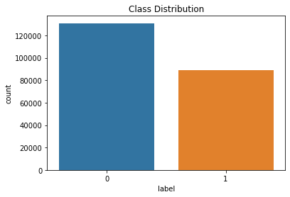

```python
# Plot the distribution of the labels
sns.countplot(x='label', data=train_data)
plt.title('Class Distribution')
plt.show()
```

### Plot Images

We are going to plot s16 images from the train set in a 4 by 4 grid.

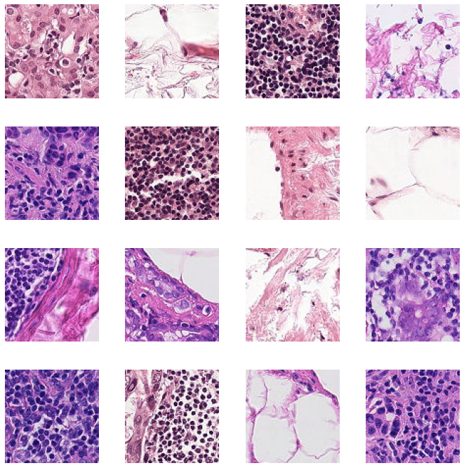

```python
# Define the path to the train folder
train_path = './train'

# List the image files in the 'train' folder
image_files = os.listdir(train_path)

# Ensure there are enough images to plot
num_images = min(16, len(image_files))  # Display up to 16 images, or however many are available

# Set up the 4x4 grid for plotting
rows, cols = 4, 4
fig, axes = plt.subplots(rows, cols, figsize=(12, 12))

# Flatten the axes array for easier indexing
axes = axes.flatten()

# Loop through and plot images
for i in range(num_images):
    # Build the full image path
    image_path = os.path.join(train_path, image_files[i])

    # Read the image using OpenCV
    image = cv2.imread(image_path)

    if image is None:
        print(f"Error: Could not load image {image_path}")
        axes[i].axis('off')  # Hide axis for missing image
        continue

    # Convert the image from BGR (OpenCV format) to RGB (for plotting with Matplotlib)
    image_rgb = cv2.cvtColor(image, cv2.COLOR_BGR2RGB)

    # Plot the image
    axes[i].imshow(image_rgb)
    axes[i].axis('off')  # Turn off axis for each image

# Hide any unused subplots
for j in range(num_images, rows * cols):
    axes[j].axis('off')

# Adjust the layout of the subplot
plt.subplots_adjust(wspace=0.1, hspace=0.3)

# Display the plot
plt.show()
```

### Add patche in the center of each image

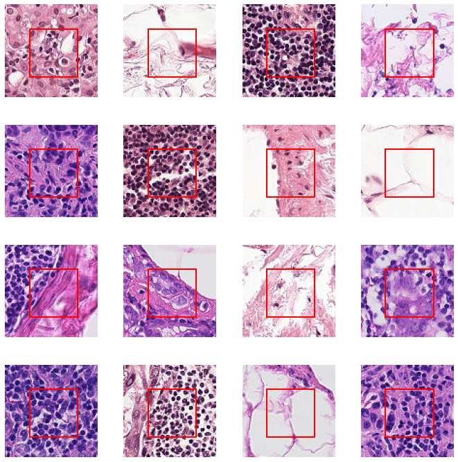

```python
# Define the path to the train folder
train_path = './train'  # Adjust the path if your folder is located elsewhere

# List the image files in the 'train' folder
image_files = os.listdir(train_path)

# Number of images to plot
num_images = 16  # 4x4 grid
cols, rows = 4, 4

# Set up the grid for plotting
fig, axes = plt.subplots(rows, cols, figsize=(12, 12))

for i in range(num_images):
    # Build the full image path
    image_path = os.path.join(train_path, image_files[i])

    # Read the image using OpenCV
    image = cv2.imread(image_path)

    # Check if the image was loaded properly
    if image is None:
        print(f"Error: Could not load image {image_path}")
        axes[i // cols, i % cols].axis('off')  # Hide axis for missing image
        continue

    # Convert the image from BGR (OpenCV) to RGB (for Matplotlib)
    image_rgb = cv2.cvtColor(image, cv2.COLOR_BGR2RGB)

    # Plot the image
    ax = axes[i // cols, i % cols]
    ax.imshow(image_rgb)

    # Add a red rectangle using patches
    rect = patches.Rectangle((25, 25), 50, 50, linewidth=2, edgecolor='red', facecolor='none')
    ax.add_patch(rect)

    ax.axis('off')  # Turn off axis for each image

# Adjust the layout of the subplot
plt.subplots_adjust(wspace=0.1, hspace=0.3)

# Display the plot
plt.show()
```